# Report Template for a Data Analysis Project

Author

Katherine Lorusso and Esther Palmer

**Authors**

- Katherine Lorusso$^{1,*}$ $\land$
- Esther Palmer$^{1,*}$

**Author affiliations**

1. College of Public Health, University of Georgia, Athens, GA, USA.

$*$ These authors contributed equally to this work.

$\land$ Corresponding author: katherine.lorusso@uga.edu

$\dagger$ Disclaimer: The opinions expressed in this article are the author’s own and don’t reflect their employer.

# 1 Introduction

## 1.1 Description of data and data source

This dataset contains variables of height, weight, eye color, age, and gender. I contributed by adding two columns on age and eye color. The eye color variable has values of Green (G), Blue (Bl), and Brown (Br). The age variable contains numberic values >0.

# 2 Methods

## 2.1 Data import and cleaning

I used a provided dataset on height, weight, and gender, while adding variables of eye color and age. I then cleaned the data by making all values numeric, converting to the same unit of measurement, and dropping missing values.

## 2.2 Statistical analysis

For statistical analysis, I used linear models to view if there was a relationship between variables.

# 3 Results

## 3.1 Exploratory/Descriptive analysis

| skim_type | skim_variable | n_missing | complete_rate | character.min | character.max | character.empty | character.n_unique | character.whitespace | factor.ordered | factor.n_unique | factor.top_counts | numeric.mean | numeric.sd | numeric.p0 | numeric.p25 | numeric.p50 | numeric.p75 | numeric.p100 | numeric.hist |
| --- | --- | --- | --- | --- | --- | --- | --- | --- | --- | --- | --- | --- | --- | --- | --- | --- | --- | --- | --- |
| character | Eye Color | 0 | 1 | 1 | 2 | 0 | 3 | 0 | NA | NA | NA | NA | NA | NA | NA | NA | NA | NA | NA |
| factor | Gender | 0 | 1 | NA | NA | NA | NA | NA | FALSE | 3 | M: 4, F: 3, O: 2 | NA | NA | NA | NA | NA | NA | NA | NA |
| numeric | Height | 0 | 1 | NA | NA | NA | NA | NA | NA | NA | NA | 165.66667 | 15.97655 | 133 | 156 | 166 | 178 | 183 | ▂▁▃▃▇ |
| numeric | Weight | 0 | 1 | NA | NA | NA | NA | NA | NA | NA | NA | 70.11111 | 21.24526 | 45 | 55 | 70 | 80 | 110 | ▇▂▃▂▂ |
| numeric | Age | 0 | 1 | NA | NA | NA | NA | NA | NA | NA | NA | 47.11111 | 11.01640 | 33 | 40 | 46 | 55 | 65 | ▇▇▇▇▃ |

## 3.2 Basic statistical analysis

The figure below is a scatterplot of Age and Weight, and it can be seen that there is no relationship between the two variables.

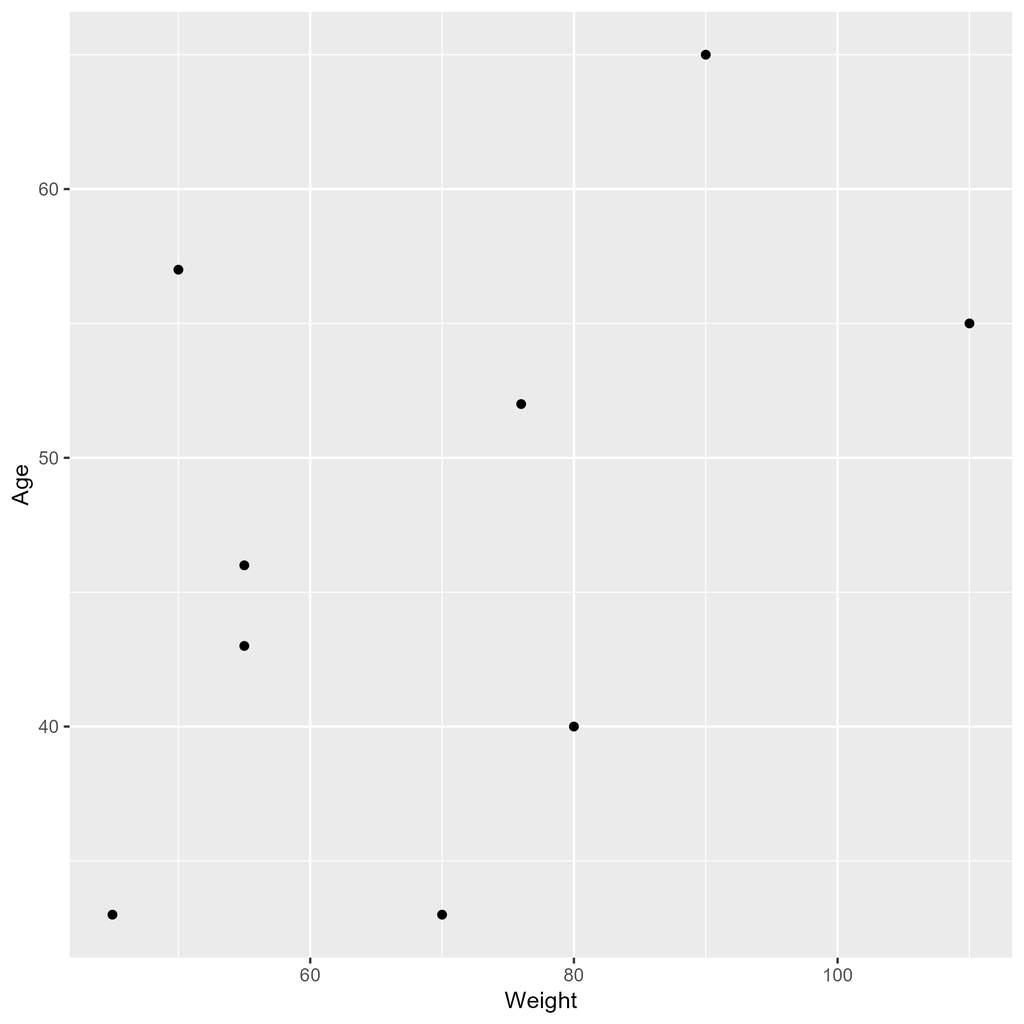

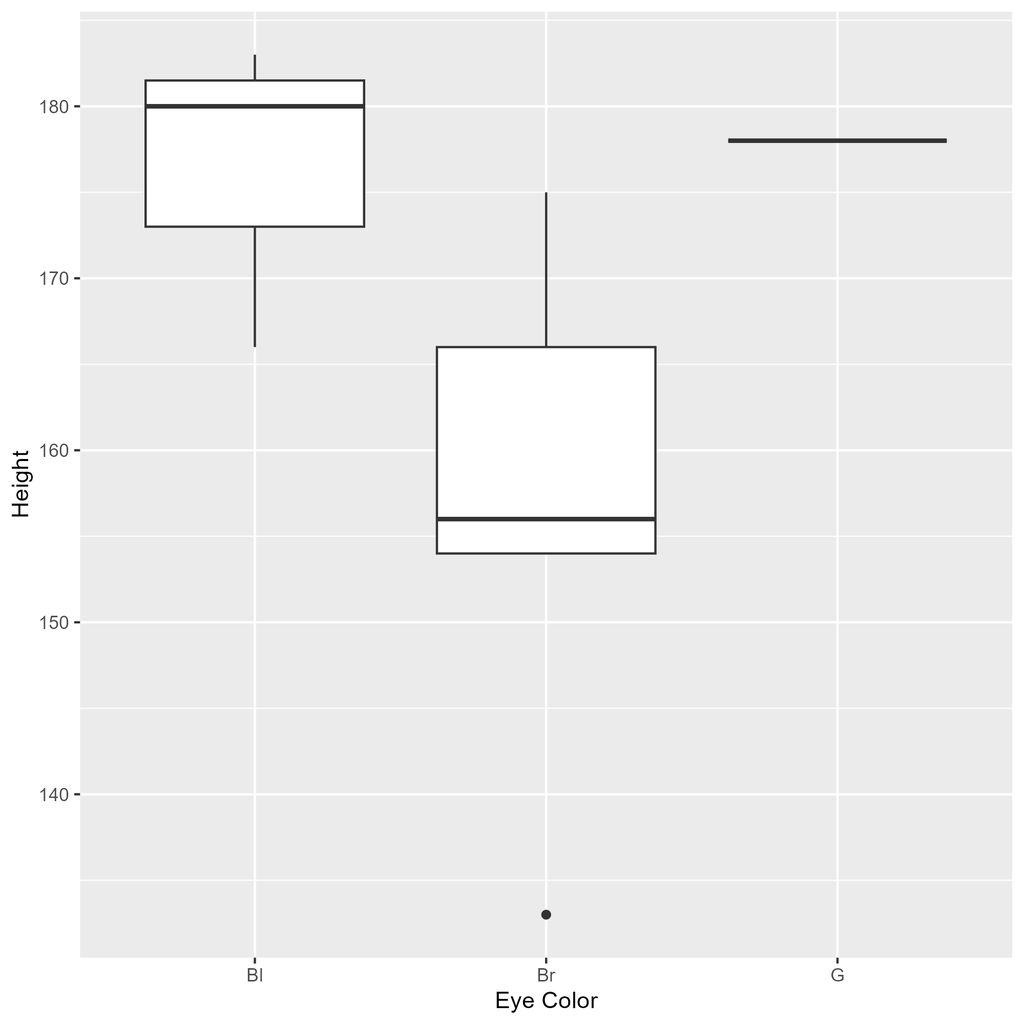

Height and Eye Color Box Plot.

## 3.3 Full analysis

The analysis below is the results of a linear model with Eye color and age as the predictors and height as the outcome.

Table 2: Linear model fit table.

| term | estimate | std.error | statistic | p.value |
| --- | --- | --- | --- | --- |
| (Intercept) | 173.0495557 | 23.605859 | 7.3307884 | 0.0007407 |
| `Eye Color`Br | -19.9609881 | 11.438946 | -1.7450023 | 0.1414303 |
| `Eye Color`G | 0.9793644 | 18.105233 | 0.0540929 | 0.9589560 |
| Age | 0.0763669 | 0.509801 | 0.1497975 | 0.8867794 |